# Sample Mean and Variance

Let $X_1, X_2, X_3,\dots,X_n$ be independent random variables having a common probability distribution with **population** mean $\mu$ and **population** variance $\sigma^2$, we say they constitute a **sample** from that distribution.

Define the **sample mean** by $$\overline{X}=\frac{X_1+X_2+X_3+\dots+X_n}{n}.$$

By the results seen earlier in the course, we have that $$E[\overline{X}] = \mu,$$ $$Var(\overline{X})=\frac{\sigma^2}{n},$$ and $$SD(\overline{X})=\frac{\sigma}{\sqrt{n}}.$$

## Comments on the Sample Mean

$$\overline{X}=\frac{X_1+X_2+X_3+\dots+X_n}{n}$$

1. We will use $X$ to mean the random variable whose distribution is the common probability distribution with population mean $\mu$ and population variance $\sigma^2$ that is being sampled.
2. The sample mean $\overline{X}$ is itself random variable! That is why we can compute its expected value and variance.
3. When $n$ is large, the standard deviation is small. This means that the sample mean will tend to clump around $\mu$ more closely if we take a large sample.
4. In many cases we do not know the $\mu$ or $\sigma$ values from the common probability distribution that we are sampling. Our goal later in the course will be to try to *infer* these values from the sample mean.
5. You might wonder, what kind of distribution does $\overline{X}$ have? We will discuss this shortly.

## Example

Consider a sample mean of size $2$ from a random variable $X$ with probability distribution $P\{X=0\} = 1/3$ and $P\{X=1\}=2/3.$

1. Compute $E[\overline{X}]$ and $Var(\overline{X})$.
2. How do your previous answers change if we increase the sample size to 10?
3. How do your previous answers change if we increase the sample size to 50?

## Probability Distribution of the Sample Mean from the Example

```python
import numpy as np
import matplotlib.pyplot as plt
import scipy as sp
```

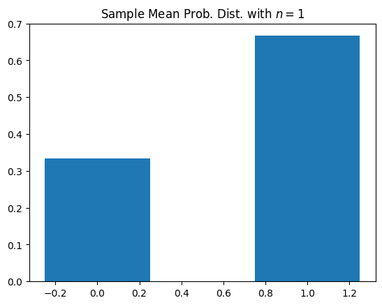

```python
X = np.array([sp.stats.bernoulli.pmf(i, 2/3) for  i in range(2)])
plt.bar(np.arange(2), X, width = 0.5)
plt.title('Sample Mean Prob. Dist. with $n=1$')
plt.show()
```

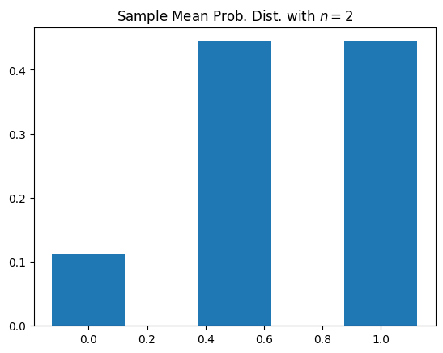

```python
X2 = np.array([sp.stats.binom.pmf(i, 2, 2/3) for  i in range(3)])
plt.bar(np.arange(3)/2, X2, width = 0.25)
plt.title('Sample Mean Prob. Dist. with $n=2$')
plt.show()
```

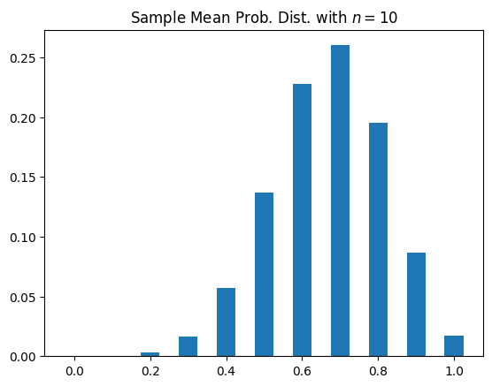

```python
X2 = np.array([sp.stats.binom.pmf(i, 10, 2/3) for  i in range(11)])
plt.bar(np.arange(11)/10, X2, width = 0.05)
plt.title('Sample Mean Prob. Dist. with $n=10$')
plt.show()
```

[figure not shown]

```python
X2 = np.array([sp.stats.binom.pmf(i, 50, 2/3) for  i in range(51)])
plt.bar(np.arange(51)/50, X2, width = 0.01)
plt.title('Sample Mean Prob. Dist. with $n=10$')
plt.show()
```

# The Central Limit Theorem (CLT)

Let $X_1, X_2, X_3,\dots,X_n$ be a sample from a population having mean $\mu$ and standard deviation $\sigma$. For $n$ large, the sum $$X_1+X_2+X_3+\dots+X_n$$ will approximately have a normal distribution with mean $n\mu$ and standard deviation $\sigma\sqrt{n}$.

This also means that $\overline{X}$ will have approximately a normal distribution with mean $\mu$ and standard deviation $\frac{\sigma}{\sqrt{n}}.$

Furthemore, the random variable $\frac{\overline{X}-\mu}{\sigma/\sqrt{n}}$ has an approximately standard normal distribution.

## Comments on the CLT

1. From a practical perspective, one might ask, how big does $n$ have to be use the CLT? Most of the time we use the standard $n>30$. This is not a rule or a theorem, but it works in many cases.
2. You will notice that the result does not depend on the distribution of the population. No matter what distribution the $X_i$s have, for large enough $n$, the sample mean starts looking like it has a normal distribution.
3. The CLT works even if the $X_i$s all have different distributions as long as none of them 'overwhelm' the others.

## Examples

1. Consider a sample of a population having mean $130$ and standard deviation $10$. Compute the probability that the sample mean will be between $120$ and $144$ when:
   1. $n=10$
   2. $n=30$
   3. $n=100$.
2. If you place a $\$1$ bet on a color of a roulette wheel, then either you win $\$1$, with probability $18/38$, or you lose $\$1$, with probability $20/38$. Let $X$ denote your gain on a bet of this type.
   1. Find $E[X]$ and $SD(X)$.
   2. Suppose you play this game 1000 times. Compute the probability that are winning after 1000 bets.

## Problem 2 Solution

```python
mu = 1*(18/38) + -1*(20/38)
mu
```

```
-0.05263157894736842
```

```python
v = (1**2)*(18/38) + ((-1)**2)*(20/38) - mu**2
v
```

```
0.997229916897507
```

```python
sd = v**0.5
sd
```

```
0.9986139979479093
```

```python
1 - sp.stats.norm.cdf(0, loc = 1000*mu, scale = sd*(1000)**0.5)
```

```
np.float64(0.047790352272814696)
```